# Optimal Treatment Analysis

## Outcome Variable

**Outcome Variable:** whz

## Predictor Variables

**Intervention Variable:** predexfd6

**Adjustment Set:**

- arm
- sex
- brthmon
- W_mage
- meducyrs
- feducyrs
- hhwealth_quart
- hfoodsec
- W_mhtcm
- W_mwtkg
- W_mbmi
- vagbrth
- W_gagebrth
- W_birthwt
- W_birthlen
- W_nrooms
- W_nchldlt5
- month
- W_parity
- impfloor
- impsan
- safeh20
- delta_W_mage
- delta_meducyrs
- delta_feducyrs
- delta_hhwealth_quart
- delta_hfoodsec
- delta_W_mhtcm
- delta_W_mwtkg
- delta_W_mbmi
- delta_vagbrth
- delta_W_gagebrth
- delta_W_birthwt
- delta_W_birthlen
- delta_W_nrooms
- delta_W_nchldlt5
- delta_month
- delta_W_parity
- delta_impfloor
- delta_impsan
- delta_safeh20

## Stratifying Variables

The analysis was stratified on these variable(s):

- agecat
- studyid
- country

## Data Summary

| agecat | studyid | country | predexfd6 | n_cell | n |
| --- | --- | --- | --- | --- | --- |
| Birth | ki0047075b-MAL-ED | BANGLADESH | 1 | 68 | 194 |
| Birth | ki0047075b-MAL-ED | BANGLADESH | 0 | 126 | 194 |
| Birth | ki0047075b-MAL-ED | BRAZIL | 1 | 5 | 57 |
| Birth | ki0047075b-MAL-ED | BRAZIL | 0 | 52 | 57 |
| Birth | ki0047075b-MAL-ED | INDIA | 1 | 4 | 37 |
| Birth | ki0047075b-MAL-ED | INDIA | 0 | 33 | 37 |
| Birth | ki0047075b-MAL-ED | NEPAL | 1 | 3 | 23 |
| Birth | ki0047075b-MAL-ED | NEPAL | 0 | 20 | 23 |
| Birth | ki0047075b-MAL-ED | PERU | 1 | 72 | 208 |
| Birth | ki0047075b-MAL-ED | PERU | 0 | 136 | 208 |
| Birth | ki0047075b-MAL-ED | SOUTH AFRICA | 1 | 1 | 90 |
| Birth | ki0047075b-MAL-ED | SOUTH AFRICA | 0 | 89 | 90 |
| Birth | ki0047075b-MAL-ED | TANZANIA, UNITED REPUBLIC OF | 1 | 0 | 105 |
| Birth | ki0047075b-MAL-ED | TANZANIA, UNITED REPUBLIC OF | 0 | 105 | 105 |
| Birth | ki1000108-CMC-V-BCS-2002 | INDIA | 1 | 7 | 7 |
| Birth | ki1000108-CMC-V-BCS-2002 | INDIA | 0 | 0 | 7 |
| Birth | ki1000108-IRC | INDIA | 1 | 0 | 12 |
| Birth | ki1000108-IRC | INDIA | 0 | 12 | 12 |
| Birth | ki1000109-EE | PAKISTAN | 1 | 24 | 28 |
| Birth | ki1000109-EE | PAKISTAN | 0 | 4 | 28 |
| Birth | ki1000304b-SAS-CompFeed | INDIA | 1 | 310 | 325 |
| Birth | ki1000304b-SAS-CompFeed | INDIA | 0 | 15 | 325 |
| Birth | ki1017093b-PROVIDE | BANGLADESH | 1 | 155 | 532 |
| Birth | ki1017093b-PROVIDE | BANGLADESH | 0 | 377 | 532 |
| Birth | ki1101329-Keneba | GAMBIA | 1 | 450 | 1327 |
| Birth | ki1101329-Keneba | GAMBIA | 0 | 877 | 1327 |
| Birth | ki1113344-GMS-Nepal | NEPAL | 1 | 390 | 522 |
| Birth | ki1113344-GMS-Nepal | NEPAL | 0 | 132 | 522 |
| Birth | kiGH5241-JiVitA-3 | BANGLADESH | 1 | 10161 | 13000 |
| Birth | kiGH5241-JiVitA-3 | BANGLADESH | 0 | 2839 | 13000 |

[output cut: 70 more lines]

The following strata were considered:

- agecat: 24 months, studyid: ki0047075b-MAL-ED, country: BANGLADESH
- agecat: 24 months, studyid: ki0047075b-MAL-ED, country: BRAZIL
- agecat: 24 months, studyid: ki0047075b-MAL-ED, country: INDIA
- agecat: 24 months, studyid: ki0047075b-MAL-ED, country: NEPAL
- agecat: 24 months, studyid: ki0047075b-MAL-ED, country: PERU
- agecat: 24 months, studyid: ki0047075b-MAL-ED, country: SOUTH AFRICA
- agecat: 24 months, studyid: ki0047075b-MAL-ED, country: TANZANIA, UNITED REPUBLIC OF
- agecat: 24 months, studyid: ki1000108-CMC-V-BCS-2002, country: INDIA
- agecat: 24 months, studyid: ki1000108-IRC, country: INDIA
- agecat: 24 months, studyid: ki1000109-EE, country: PAKISTAN
- agecat: 24 months, studyid: ki1017093b-PROVIDE, country: BANGLADESH
- agecat: 24 months, studyid: ki1101329-Keneba, country: GAMBIA
- agecat: 24 months, studyid: ki1113344-GMS-Nepal, country: NEPAL
- agecat: 24 months, studyid: ki1148112-LCNI-5, country: MALAWI
- agecat: 24 months, studyid: kiGH5241-JiVitA-3, country: BANGLADESH
- agecat: 24 months, studyid: kiGH5241-JiVitA-4, country: BANGLADESH
- agecat: 6 months, studyid: ki0047075b-MAL-ED, country: BANGLADESH
- agecat: 6 months, studyid: ki0047075b-MAL-ED, country: BRAZIL
- agecat: 6 months, studyid: ki0047075b-MAL-ED, country: INDIA
- agecat: 6 months, studyid: ki0047075b-MAL-ED, country: NEPAL
- agecat: 6 months, studyid: ki0047075b-MAL-ED, country: PERU
- agecat: 6 months, studyid: ki0047075b-MAL-ED, country: SOUTH AFRICA
- agecat: 6 months, studyid: ki0047075b-MAL-ED, country: TANZANIA, UNITED REPUBLIC OF
- agecat: 6 months, studyid: ki1000108-CMC-V-BCS-2002, country: INDIA
- agecat: 6 months, studyid: ki1000108-IRC, country: INDIA
- agecat: 6 months, studyid: ki1000109-EE, country: PAKISTAN
- agecat: 6 months, studyid: ki1000304b-SAS-CompFeed, country: INDIA
- agecat: 6 months, studyid: ki1000304b-SAS-FoodSuppl, country: INDIA
- agecat: 6 months, studyid: ki1017093b-PROVIDE, country: BANGLADESH
- agecat: 6 months, studyid: ki1101329-Keneba, country: GAMBIA
- agecat: 6 months, studyid: ki1113344-GMS-Nepal, country: NEPAL
- agecat: 6 months, studyid: ki1148112-LCNI-5, country: MALAWI
- agecat: 6 months, studyid: kiGH5241-JiVitA-3, country: BANGLADESH
- agecat: 6 months, studyid: kiGH5241-JiVitA-4, country: BANGLADESH
- agecat: Birth, studyid: ki0047075b-MAL-ED, country: BANGLADESH
- agecat: Birth, studyid: ki0047075b-MAL-ED, country: BRAZIL
- agecat: Birth, studyid: ki0047075b-MAL-ED, country: INDIA
- agecat: Birth, studyid: ki0047075b-MAL-ED, country: NEPAL
- agecat: Birth, studyid: ki0047075b-MAL-ED, country: PERU
- agecat: Birth, studyid: ki0047075b-MAL-ED, country: SOUTH AFRICA
- agecat: Birth, studyid: ki0047075b-MAL-ED, country: TANZANIA, UNITED REPUBLIC OF
- agecat: Birth, studyid: ki1000108-CMC-V-BCS-2002, country: INDIA
- agecat: Birth, studyid: ki1000108-IRC, country: INDIA
- agecat: Birth, studyid: ki1000109-EE, country: PAKISTAN
- agecat: Birth, studyid: ki1000304b-SAS-CompFeed, country: INDIA
- agecat: Birth, studyid: ki1017093b-PROVIDE, country: BANGLADESH
- agecat: Birth, studyid: ki1101329-Keneba, country: GAMBIA
- agecat: Birth, studyid: ki1113344-GMS-Nepal, country: NEPAL
- agecat: Birth, studyid: kiGH5241-JiVitA-3, country: BANGLADESH
- agecat: Birth, studyid: kiGH5241-JiVitA-4, country: BANGLADESH

### Dropped Strata

Some strata were dropped due to rare outcomes:

- agecat: Birth, studyid: ki0047075b-MAL-ED, country: INDIA
- agecat: Birth, studyid: ki0047075b-MAL-ED, country: NEPAL
- agecat: Birth, studyid: ki0047075b-MAL-ED, country: SOUTH AFRICA
- agecat: Birth, studyid: ki0047075b-MAL-ED, country: TANZANIA, UNITED REPUBLIC OF
- agecat: Birth, studyid: ki1000108-CMC-V-BCS-2002, country: INDIA
- agecat: Birth, studyid: ki1000108-IRC, country: INDIA
- agecat: Birth, studyid: ki1000109-EE, country: PAKISTAN
- agecat: 6 months, studyid: ki0047075b-MAL-ED, country: SOUTH AFRICA
- agecat: 6 months, studyid: ki0047075b-MAL-ED, country: TANZANIA, UNITED REPUBLIC OF
- agecat: 6 months, studyid: ki1000108-CMC-V-BCS-2002, country: INDIA
- agecat: 6 months, studyid: ki1000108-IRC, country: INDIA
- agecat: 6 months, studyid: ki1000304b-SAS-FoodSuppl, country: INDIA
- agecat: 24 months, studyid: ki0047075b-MAL-ED, country: SOUTH AFRICA
- agecat: 24 months, studyid: ki0047075b-MAL-ED, country: TANZANIA, UNITED REPUBLIC OF
- agecat: 24 months, studyid: ki1000108-CMC-V-BCS-2002, country: INDIA
- agecat: 24 months, studyid: ki1000108-IRC, country: INDIA
- agecat: 24 months, studyid: ki1000109-EE, country: PAKISTAN

## Methods Detail

We’re interested in the causal parameters $E[Y_a]$ for all values of $a \in \mathcal{A}$. These parameters represent the mean outcome if, possibly contrary to fact, we intervened to set all units to have $A=a$. Under the randomization and positivity assumptions, these are identified by the statistical parameters $\psi_a=E_W[E_{Y|A,W}(Y|A=a,W)]$. In addition, we’re interested in the mean of $Y$, $E[Y]$ under no intervention (the observed mean). We will estimate these parameters by using SuperLearner to fit the relevant likelihood factors – $E_{Y|A,W}(Y|A=a,W)$ and $p(A=a|W)$, and then updating our likelihood fit using a joint TMLE.

For unadjusted analyses ($W=\{\}$), initial likelihoods were estimated using Lrnr_glm to estimate the simple $E(Y|A)$ and Lrnr_mean to estimate $p(A)$. For adjusted analyses, a small library containing Lrnr_glmnet, Lrnr_xgboost, and Lrnr_mean was used.

Having estimated these parameters, we will then use the delta method to estimate relative risks and attributable risks relative to a prespecified baseline level of $A$.

# Results Detail

## Results Plots

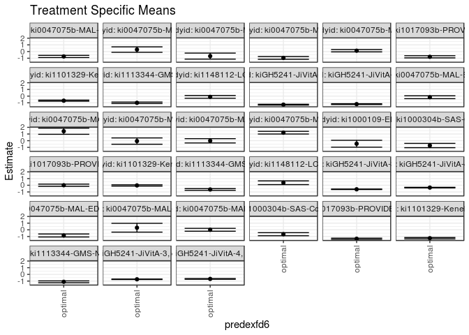

## Results Table

### Parameter: TSM

| agecat | studyid | country | intervention_level | baseline_level | estimate | ci_lower | ci_upper |
| --- | --- | --- | --- | --- | --- | --- | --- |
| Birth | ki0047075b-MAL-ED | BANGLADESH | optimal | observed | -0.8470796 | -1.0695736 | -0.6245856 |
| Birth | ki0047075b-MAL-ED | BRAZIL | optimal | observed | 0.3157356 | -0.3440032 | 0.9754744 |
| Birth | ki0047075b-MAL-ED | PERU | optimal | observed | 0.0044587 | -0.2137649 | 0.2226824 |
| Birth | ki1000304b-SAS-CompFeed | INDIA | optimal | observed | -0.6562835 | -0.8852815 | -0.4272855 |
| Birth | ki1017093b-PROVIDE | BANGLADESH | optimal | observed | -1.3414961 | -1.4338078 | -1.2491845 |
| Birth | ki1101329-Keneba | GAMBIA | optimal | observed | -1.2551901 | -1.3561723 | -1.1542078 |
| Birth | ki1113344-GMS-Nepal | NEPAL | optimal | observed | -1.1106806 | -1.2513380 | -0.9700232 |
| Birth | kiGH5241-JiVitA-3 | BANGLADESH | optimal | observed | -0.7347476 | -0.7685246 | -0.7009707 |
| Birth | kiGH5241-JiVitA-4 | BANGLADESH | optimal | observed | -0.6755257 | -0.7303612 | -0.6206902 |
| 6 months | ki0047075b-MAL-ED | BANGLADESH | optimal | observed | -0.1673637 | -0.3820783 | 0.0473510 |
| 6 months | ki0047075b-MAL-ED | BRAZIL | optimal | observed | 1.4162863 | 0.9550197 | 1.8775528 |
| 6 months | ki0047075b-MAL-ED | INDIA | optimal | observed | -0.0601293 | -0.5315295 | 0.4112709 |
| 6 months | ki0047075b-MAL-ED | NEPAL | optimal | observed | -0.0199039 | -0.3418083 | 0.3020005 |
| 6 months | ki0047075b-MAL-ED | PERU | optimal | observed | 1.1988653 | 0.9981648 | 1.3995657 |
| 6 months | ki1000109-EE | PAKISTAN | optimal | observed | -0.4573174 | -0.9737693 | 0.0591346 |
| 6 months | ki1000304b-SAS-CompFeed | INDIA | optimal | observed | -0.7249143 | -1.0477394 | -0.4020893 |
| 6 months | ki1017093b-PROVIDE | BANGLADESH | optimal | observed | 0.0041651 | -0.1636632 | 0.1719935 |
| 6 months | ki1101329-Keneba | GAMBIA | optimal | observed | -0.0263989 | -0.1240239 | 0.0712260 |
| 6 months | ki1113344-GMS-Nepal | NEPAL | optimal | observed | -0.6315701 | -0.7585632 | -0.5045769 |
| 6 months | ki1148112-LCNI-5 | MALAWI | optimal | observed | 0.3762070 | 0.0946721 | 0.6577419 |
| 6 months | kiGH5241-JiVitA-3 | BANGLADESH | optimal | observed | -0.6031839 | -0.6401500 | -0.5662177 |
| 6 months | kiGH5241-JiVitA-4 | BANGLADESH | optimal | observed | -0.3500097 | -0.3940298 | -0.3059896 |
| 24 months | ki0047075b-MAL-ED | BANGLADESH | optimal | observed | -0.7324677 | -0.8942212 | -0.5707141 |
| 24 months | ki0047075b-MAL-ED | BRAZIL | optimal | observed | 0.2934111 | -0.1162973 | 0.7031196 |
| 24 months | ki0047075b-MAL-ED | INDIA | optimal | observed | -0.6825543 | -1.1348168 | -0.2302918 |
| 24 months | ki0047075b-MAL-ED | NEPAL | optimal | observed | -0.9520574 | -1.1573049 | -0.7468099 |
| 24 months | ki0047075b-MAL-ED | PERU | optimal | observed | 0.1245923 | -0.0490250 | 0.2982097 |
| 24 months | ki1017093b-PROVIDE | BANGLADESH | optimal | observed | -0.7860849 | -0.9485905 | -0.6235794 |
| 24 months | ki1101329-Keneba | GAMBIA | optimal | observed | -0.6804258 | -0.7601638 | -0.6006879 |
| 24 months | ki1113344-GMS-Nepal | NEPAL | optimal | observed | -1.0009062 | -1.1130747 | -0.8887378 |
| 24 months | ki1148112-LCNI-5 | MALAWI | optimal | observed | -0.1160643 | -0.3202572 | 0.0881286 |
| 24 months | kiGH5241-JiVitA-3 | BANGLADESH | optimal | observed | -1.2813517 | -1.3419707 | -1.2207328 |
| 24 months | kiGH5241-JiVitA-4 | BANGLADESH | optimal | observed | -1.1992194 | -1.2585623 | -1.1398765 |

### Parameter: E(Y)

| agecat | studyid | country | intervention_level | baseline_level | estimate | ci_lower | ci_upper |
| --- | --- | --- | --- | --- | --- | --- | --- |
| Birth | ki0047075b-MAL-ED | BANGLADESH | observed | observed | -0.9748454 | -1.1280978 | -0.8215930 |
| Birth | ki0047075b-MAL-ED | BRAZIL | observed | observed | 0.4643860 | 0.1360519 | 0.7927200 |
| Birth | ki0047075b-MAL-ED | PERU | observed | observed | -0.0587981 | -0.1871869 | 0.0695908 |
| Birth | ki1000304b-SAS-CompFeed | INDIA | observed | observed | -0.6596308 | -0.9005716 | -0.4186900 |
| Birth | ki1017093b-PROVIDE | BANGLADESH | observed | observed | -1.2984586 | -1.3752758 | -1.2216415 |
| Birth | ki1101329-Keneba | GAMBIA | observed | observed | -1.2599925 | -1.3251703 | -1.1948146 |
| Birth | ki1113344-GMS-Nepal | NEPAL | observed | observed | -1.1064559 | -1.2034951 | -1.0094168 |
| Birth | kiGH5241-JiVitA-3 | BANGLADESH | observed | observed | -0.7557115 | -0.7768180 | -0.7346051 |
| Birth | kiGH5241-JiVitA-4 | BANGLADESH | observed | observed | -0.6904586 | -0.7435822 | -0.6373351 |
| 6 months | ki0047075b-MAL-ED | BANGLADESH | observed | observed | -0.1220707 | -0.2547831 | 0.0106417 |
| 6 months | ki0047075b-MAL-ED | BRAZIL | observed | observed | 0.9717225 | 0.8073791 | 1.1360658 |
| 6 months | ki0047075b-MAL-ED | INDIA | observed | observed | -0.7073471 | -0.8375598 | -0.5771344 |
| 6 months | ki0047075b-MAL-ED | NEPAL | observed | observed | 0.1097852 | -0.0259319 | 0.2455023 |
| 6 months | ki0047075b-MAL-ED | PERU | observed | observed | 1.0546617 | 0.9322137 | 1.1771098 |
| 6 months | ki1000109-EE | PAKISTAN | observed | observed | -0.6106944 | -0.9239621 | -0.2974268 |
| 6 months | ki1000304b-SAS-CompFeed | INDIA | observed | observed | -0.6348861 | -0.7630511 | -0.5067211 |
| 6 months | ki1017093b-PROVIDE | BANGLADESH | observed | observed | -0.1990907 | -0.2817968 | -0.1163845 |
| 6 months | ki1101329-Keneba | GAMBIA | observed | observed | -0.1997647 | -0.2531388 | -0.1463906 |
| 6 months | ki1113344-GMS-Nepal | NEPAL | observed | observed | -0.6009171 | -0.6886356 | -0.5131986 |
| 6 months | ki1148112-LCNI-5 | MALAWI | observed | observed | 0.3925000 | 0.2735307 | 0.5114693 |
| 6 months | kiGH5241-JiVitA-3 | BANGLADESH | observed | observed | -0.5998808 | -0.6237974 | -0.5759642 |
| 6 months | kiGH5241-JiVitA-4 | BANGLADESH | observed | observed | -0.3968456 | -0.4358721 | -0.3578192 |
| 24 months | ki0047075b-MAL-ED | BANGLADESH | observed | observed | -0.8179024 | -0.9399789 | -0.6958260 |
| 24 months | ki0047075b-MAL-ED | BRAZIL | observed | observed | 0.4592308 | 0.2528453 | 0.6656163 |
| 24 months | ki0047075b-MAL-ED | INDIA | observed | observed | -0.9449522 | -1.0648865 | -0.8250178 |
| 24 months | ki0047075b-MAL-ED | NEPAL | observed | observed | -0.3690411 | -0.4853679 | -0.2527143 |
| 24 months | ki0047075b-MAL-ED | PERU | observed | observed | 0.1204478 | 0.0005049 | 0.2403906 |
| 24 months | ki1017093b-PROVIDE | BANGLADESH | observed | observed | -0.8928670 | -0.9755153 | -0.8102187 |
| 24 months | ki1101329-Keneba | GAMBIA | observed | observed | -0.8032329 | -0.8532842 | -0.7531817 |
| 24 months | ki1113344-GMS-Nepal | NEPAL | observed | observed | -1.1423525 | -1.2336321 | -1.0510729 |
| 24 months | ki1148112-LCNI-5 | MALAWI | observed | observed | -0.0770652 | -0.2204213 | 0.0662909 |
| 24 months | kiGH5241-JiVitA-3 | BANGLADESH | observed | observed | -1.3113405 | -1.3420927 | -1.2805883 |
| 24 months | kiGH5241-JiVitA-4 | BANGLADESH | observed | observed | -1.2265320 | -1.2620508 | -1.1910132 |

### Parameter: PAR

| agecat | studyid | country | intervention_level | baseline_level | estimate | ci_lower | ci_upper |
| --- | --- | --- | --- | --- | --- | --- | --- |
| Birth | ki0047075b-MAL-ED | BANGLADESH | optimal | observed | -0.1277657 | -0.3226545 | 0.0671230 |
| Birth | ki0047075b-MAL-ED | BRAZIL | optimal | observed | 0.1486504 | -0.4053382 | 0.7026389 |
| Birth | ki0047075b-MAL-ED | PERU | optimal | observed | -0.0632568 | -0.2454051 | 0.1188915 |
| Birth | ki1000304b-SAS-CompFeed | INDIA | optimal | observed | -0.0033473 | -0.0446450 | 0.0379504 |
| Birth | ki1017093b-PROVIDE | BANGLADESH | optimal | observed | 0.0430375 | -0.0145635 | 0.1006385 |
| Birth | ki1101329-Keneba | GAMBIA | optimal | observed | -0.0048024 | -0.0825853 | 0.0729805 |
| Birth | ki1113344-GMS-Nepal | NEPAL | optimal | observed | 0.0042246 | -0.1004586 | 0.1089079 |
| Birth | kiGH5241-JiVitA-3 | BANGLADESH | optimal | observed | -0.0209639 | -0.0486608 | 0.0067330 |
| Birth | kiGH5241-JiVitA-4 | BANGLADESH | optimal | observed | -0.0149329 | -0.0422412 | 0.0123754 |
| 6 months | ki0047075b-MAL-ED | BANGLADESH | optimal | observed | 0.0452930 | -0.0912498 | 0.1818357 |
| 6 months | ki0047075b-MAL-ED | BRAZIL | optimal | observed | -0.4445638 | -0.8682134 | -0.0209142 |
| 6 months | ki0047075b-MAL-ED | INDIA | optimal | observed | -0.6472178 | -1.1148015 | -0.1796341 |
| 6 months | ki0047075b-MAL-ED | NEPAL | optimal | observed | 0.1296890 | -0.1902076 | 0.4495857 |
| 6 months | ki0047075b-MAL-ED | PERU | optimal | observed | -0.1442035 | -0.3122124 | 0.0238053 |
| 6 months | ki1000109-EE | PAKISTAN | optimal | observed | -0.1533771 | -0.7268881 | 0.4201339 |
| 6 months | ki1000304b-SAS-CompFeed | INDIA | optimal | observed | 0.0900283 | -0.2741145 | 0.4541710 |
| 6 months | ki1017093b-PROVIDE | BANGLADESH | optimal | observed | -0.2032558 | -0.3518048 | -0.0547068 |
| 6 months | ki1101329-Keneba | GAMBIA | optimal | observed | -0.1733657 | -0.2535861 | -0.0931454 |
| 6 months | ki1113344-GMS-Nepal | NEPAL | optimal | observed | 0.0306529 | -0.0543611 | 0.1156669 |
| 6 months | ki1148112-LCNI-5 | MALAWI | optimal | observed | 0.0162930 | -0.2187105 | 0.2512965 |
| 6 months | kiGH5241-JiVitA-3 | BANGLADESH | optimal | observed | 0.0033031 | -0.0271278 | 0.0337339 |
| 6 months | kiGH5241-JiVitA-4 | BANGLADESH | optimal | observed | -0.0468359 | -0.0691577 | -0.0245141 |
| 24 months | ki0047075b-MAL-ED | BANGLADESH | optimal | observed | -0.0854348 | -0.1766298 | 0.0057603 |
| 24 months | ki0047075b-MAL-ED | BRAZIL | optimal | observed | 0.1658196 | -0.1925356 | 0.5241748 |
| 24 months | ki0047075b-MAL-ED | INDIA | optimal | observed | -0.2623978 | -0.7092096 | 0.1844139 |
| 24 months | ki0047075b-MAL-ED | NEPAL | optimal | observed | 0.5830163 | 0.3775348 | 0.7884979 |
| 24 months | ki0047075b-MAL-ED | PERU | optimal | observed | -0.0041446 | -0.1283947 | 0.1201056 |
| 24 months | ki1017093b-PROVIDE | BANGLADESH | optimal | observed | -0.1067821 | -0.2489752 | 0.0354111 |
| 24 months | ki1101329-Keneba | GAMBIA | optimal | observed | -0.1228071 | -0.1869056 | -0.0587086 |
| 24 months | ki1113344-GMS-Nepal | NEPAL | optimal | observed | -0.1414463 | -0.2189893 | -0.0639032 |
| 24 months | ki1148112-LCNI-5 | MALAWI | optimal | observed | 0.0389991 | -0.0831803 | 0.1611784 |
| 24 months | kiGH5241-JiVitA-3 | BANGLADESH | optimal | observed | -0.0299888 | -0.0816688 | 0.0216913 |
| 24 months | kiGH5241-JiVitA-4 | BANGLADESH | optimal | observed | -0.0273126 | -0.0715194 | 0.0168942 |